# Some Statistics With R

Federico Dotti

2023-02-03

## In this document, we explore a series of methods of high importance in statistics (Monte Carlo methods). Lastly, we train a model to predict the stage of ALS (Amyotrophic Lateral Sclerosis) based on a series of biomarkers.

### [Rejection Sampling](https://en.wikipedia.org/wiki/Rejection_sampling), an example

Rejection sampling is a method whereby we can generate samples from a desired random variable provided that we know its density, and that we already know how to sample from a different distribution whose support contains that of the target random variable.

Consider the triangular distribution with density $f(x) = 2-4\mid x-\frac{1}{2} \mid$ when $x \in (0,1)$ and $f(x) = 0$ otherwise

The density function looks as follows:

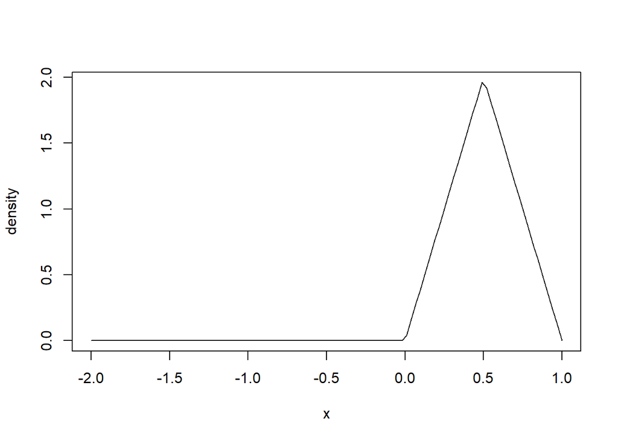

```r
triang = function(x)
{
  (2 - 4*abs(x-0.5))*I((x>0)&(x<1))
}

curve(triang,-2,1,xlab="x",ylab="density")
```

Using a uniform random variable on the interval $(0,1)$ to sample from the triangular density with rejection sampling:

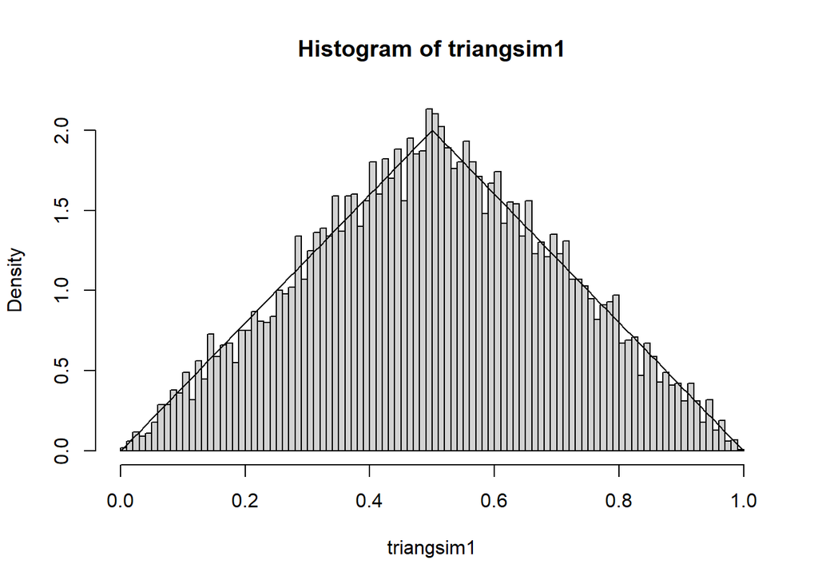

```r
b=optimize(function(x) triang(x),c(0,1),maximum = T)$objective #objective is the value of max, not the argument, using uniform as proposal
#maximization is done over the interval (0,1)

triangular.AR = function(n)
{
  out=NULL
  while (length(out)<n)
  {
    xstar=runif(1)
    u=runif(1)
    if (u*b<triang(xstar))
    {
      out=c(out,xstar)
    }
  }
  out
}

triangsim1=triangular.AR(10^4)
hist(triangsim1,freq=F,nclass=100)
curve(triang(x),add=T)
```

Now we’ll use a Beta(2,2) as the proposal distribution:

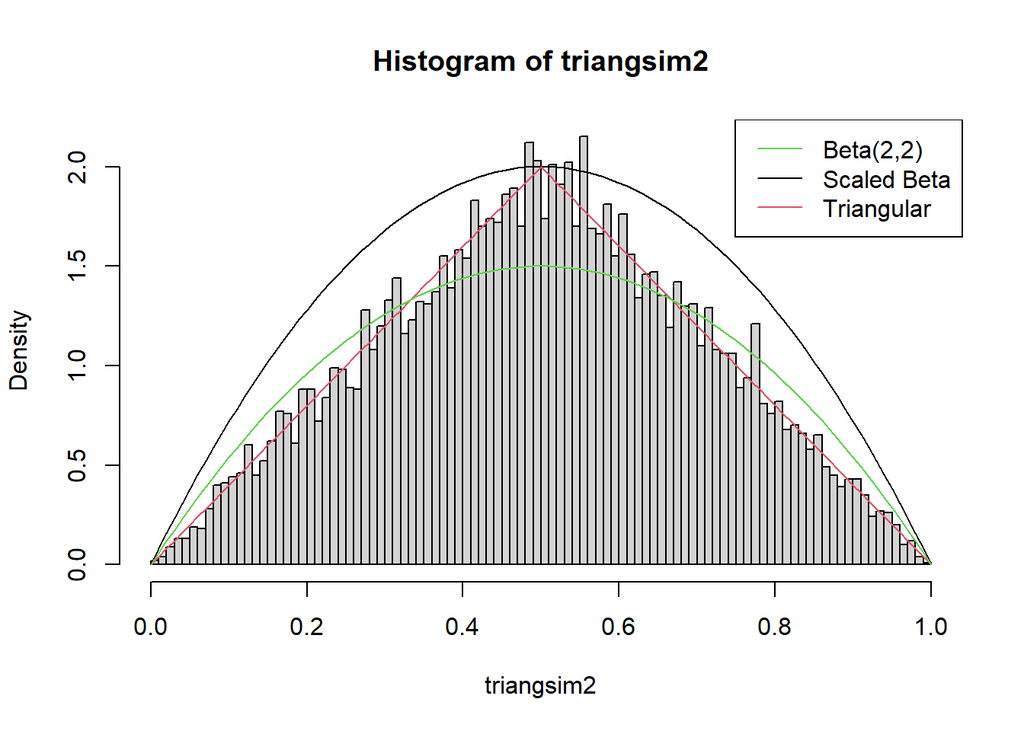

```r
b=optimize(function(x) triang(x)/dbeta(x,2,2),c(0,1),maximum = T)$objective #objective is the value of max, not the argument, using uniform as proposal
#maximization is done over the interval (0,1)


triangular.AR2 = function(n)
{
  out=NULL
  while (length(out)<n)
  {
    xstar=rbeta(1,2,2)
    u=runif(1)
    if (u*b*dbeta(xstar,2,2)<triang(xstar))
    {
      out=c(out,xstar)
    }
  }
  out
}

triangsim2=triangular.AR2(10^4)
hist(triangsim2,freq=F,nclass=100)
curve(b*dbeta(x,shape1 = 2,shape2 = 2),add=T) #plot of proposal
curve(triang(x), add = T, col=2) #plot of desired function
curve(dbeta(x,shape1 = 2,shape2 = 2),add=T, col=3)
legend(x = "topright", legend = c("Beta(2,2)", "Scaled Beta", "Triangular"),
       lty = c(1,1,1), col = c(3,1,2))
```

### Monte Carlo integration

Any algorithm that repeatedly uses samples from a probability distribution can be called a Monte Carlo method. We can calculate integrals numerically by generating from a random variable whose support includes the domain of integration. We will calculate
$$\int_{0}^{\infty}e^{-x^3}dx \approx
0.89298$$

If $X$ is a standard normal random variable and $f(x)=\frac{1}{A(x)}e^{-x^3}$ when $x>0$ and $f(x)=0$ otherwise, where $A(x)$ is the probability density function of $X$, then
$$\mathbb{E}[f(X)] =
\int_{0}^{\infty}A(x)f(x)dx = \int_{0}^{\infty}A(x)\frac{1}{A(x)}
e^{-x^3}dx = \int_{0}^{\infty}e^{-x^3}dx$$

We will calculate this expected value numerically by taking multiple samples from $X$, applying the function $f$, and averaging the results.

```r
normgen = function(x)
{
  sqrt(2*pi)*exp((x^2)/2)*exp(-x^3)*I(x>0)
}
```

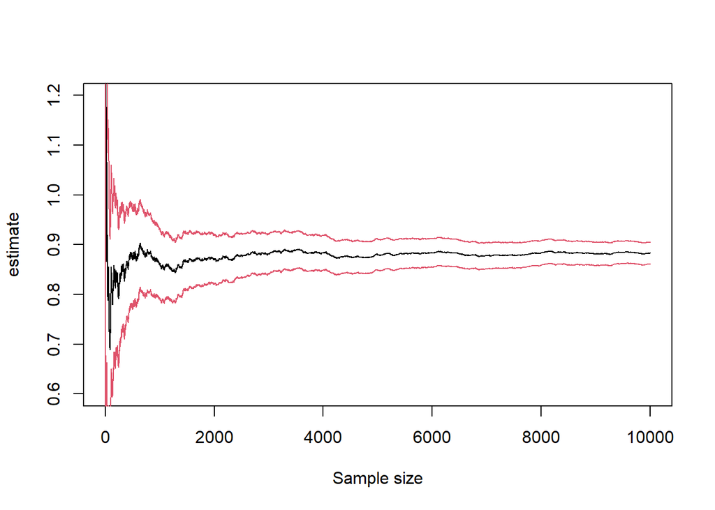

```r
normsim = function(n)
{
  x=rnorm(n)
  fx=normgen(x)
  value=cumsum(fx)/1:n
  var=cumsum(fx^2)/1:n
  var=var-(value^2)
  var=var/1:n
  out=list(value = value, var = var)
}

normsim1 = normsim(10^4)
plot(normsim1$value,type="l",ylim = c(0.6,1.2), xlab = "Sample size",
     ylab = "estimate") #ylim chosen a posteriori
lines(1:10^4,normsim1$value+2*sqrt(normsim1$var),type ="l",col=2)
lines(1:10^4,normsim1$value-2*sqrt(normsim1$var),type ="l",col=2)
```

We can create a matrix with b rows and n columns, where each row corresponds to an estimate of sample size n. We can use the quantiles (97.5 per cent and 2.5 per cent) to plot variability bands. In this example, the resulting graph will be much smoother because it will be based on 200 simulations rather than just one:

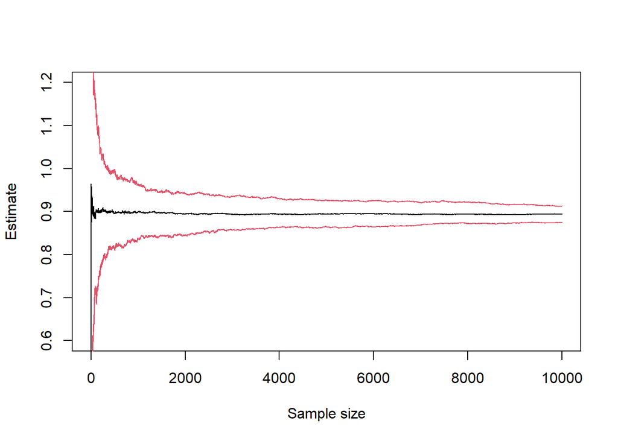

```r
normsimq = function(b,n)
{
  out=matrix(NA,b,n)
  for (i in 1:b)
  {
  x=rnorm(n)
  fx=normgen(x)
  value=cumsum(fx)/1:n
  out[i,]=value
  }
  out

}

normsimq1 = normsimq(200,10^4)
upper=rep(NA,10^4)
middle=rep(NA,10^4)
lower=rep(NA,10^4)
for (i in 1:10^4)
{
  upper[i]=quantile(normsimq1[,i],probs = 0.975)
  middle[i]=quantile(normsimq1[,i],probs = 0.5)
  lower[i]=quantile(normsimq1[,i],probs = 0.025)
}
plot(1:10^4,middle,type="l",ylim=c(0.6,1.2),
     xlab = "Sample size", ylab = "Estimate")
lines(1:10^4,upper,type="l",col=2)
lines(1:10^4,lower,type="l",col=2)
```

Now we will calculate the expected value of the distribution that is proportional to $f(x)=e^{-x^2{\sqrt{x}}}\sin^2{(x)}$ where $x>0$ and $f(x)=0$ otherwise, by generating samples from an exponential random variable with $\lambda = 1$, the logic is the same as before.

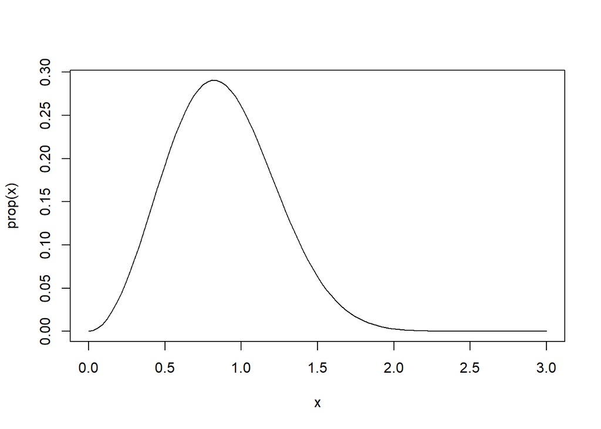

```r
prop = function(x) exp(-x^2*(sqrt(x)))*sin(x)^2

curve(prop, 0, 3)
```

```r
a=integrate(function(x) exp(-x^2*(sqrt(x)))*sin(x)^2,0,Inf)
cat("The integral of f over the positive reals is", a$value)
```

```
## The integral of f over the positive reals is 0.259539
```

```r
a=1/a$value
fun = function(x) a*I(x>0)*exp(-x^2*(sqrt(x)))*sin(x)^2 #Turn our function into a probability density by making it integrate to 1
nonMCEV=integrate(function(x) x*fun(x),0,Inf)$value #Deterministic calculation of Expected value
cat("The expexted value calculated with conventional methods", nonMCEV)
```

```
## The expexted value calculated with conventional methods 0.8791247
```

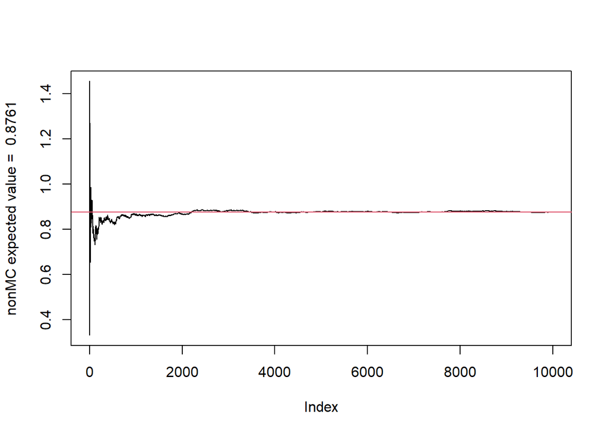

```r
importancesam = function(n)
{
  val=rexp(n)
  function2=function(x) a*exp(x-(x^(5/2)))*(sin(x)^2)*x #original function multiplied by x and by the reciprocal of the density of an exponential rv with parameter lambda = 1
  val2=function2(val)
  estimate=cumsum(val2)/1:n
  out=estimate
}

importancesim = importancesam(10^4)
plot(importancesim,type="l", ylab = paste("nonMC expected value = ",as.character(round(importancesim[10^4], digits = 4))))
abline(h=importancesim[10^4],col=2)
```

### Bootstrapping to make inferences about a parameter

The dataset `cats` from the MASS library contains measurements about the body weight (in kilograms) and the heart weight (in grams) of domestic cats. We are interested in knowing whether, on average, male cats have a higher heart weight relative to their bodyweight than female cats. We only have one sample of 144 observations, and we will use bootstrapping (sampling with replacement) to generate 1000 samples of 144 observations to obtain the sampling distribution for the parameter.

```r
library(boot)
library(MASS)
head(cats)
```

```
##   Sex Bwt Hwt
## 1   F 2.0 7.0
## 2   F 2.0 7.4
## 3   F 2.0 9.5
## 4   F 2.1 7.2
## 5   F 2.1 7.3
## 6   F 2.1 7.6
```

```r
mean(cats$Hwt[cats$Sex=="M"])/mean(cats$Bwt[cats$Sex=="M"])-mean(cats$Hwt[cats$Sex=="F"])/mean(cats$Bwt[cats$Sex=="F"])
```

```
## [1] 0.004462727
```

We can see that in the original sample the parameter is essentially equal to 0, indicating that there is no difference between the sexes.

```r
theta=function(data,i)
{
  d=data[i,]
  mean(d$Hwt[d$Sex=="M"])/mean(d$Bwt[d$Sex=="M"])-mean(d$Hwt[d$Sex=="F"])/mean(d$Bwt[d$Sex=="F"])
}

cats.boot=boot(cats,theta,R=1000,strata=cats$Sex) #Use strata if the indices are partitioned (In this case by Sex)
cats.boot$t0
```

```
## [1] 0.004462727
```

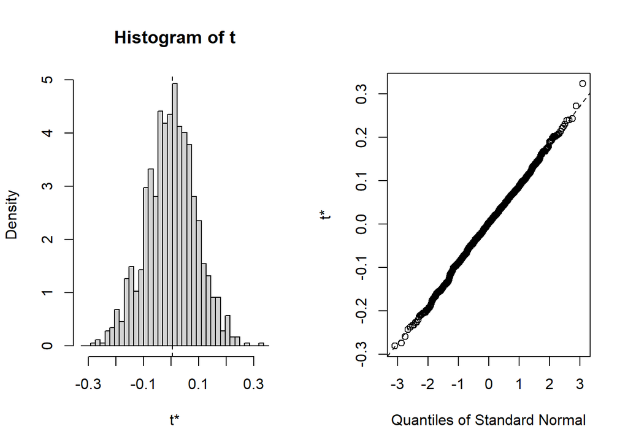

```r
plot(cats.boot)
```

```r
cats.boot
```

```
##
## STRATIFIED BOOTSTRAP
##
##
## Call:
## boot(data = cats, statistic = theta, R = 1000, strata = cats$Sex)
##
##
## Bootstrap Statistics :
##        original       bias    std. error
## t1* 0.004462727 -0.005188145  0.09099217
```

```r
boot.ci(cats.boot,conf=0.99)
```

```
## BOOTSTRAP CONFIDENCE INTERVAL CALCULATIONS
## Based on 1000 bootstrap replicates
##
## CALL :
## boot.ci(boot.out = cats.boot, conf = 0.99)
##
## Intervals :
## Level      Normal              Basic
## 99%   (-0.2247,  0.2440 )   (-0.2290,  0.2466 )
##
## Level     Percentile            BCa
## 99%   (-0.2377,  0.2379 )   (-0.2328,  0.2397 )
## Calculations and Intervals on Original Scale
## Some basic intervals may be unstable
## Some percentile intervals may be unstable
## Some BCa intervals may be unstable
```

The bootstrap confidence intervals are symmetric around 0, concordant with our initial estimate.

### Predicting Disease Stage Based on a Series of Biomarkers

ALS (Amyotrophic Lateral Sclerosis) is a neurodegenerative disease that affects the motor neurons that control voluntary muscles until the eventual paralysis and death of the patient. Usually, the prognosis is that the patient will have 3 to 5 years to live after the first time symptoms arise. The data set `sla.csv` was obtained from a database that contains data from patients participating in clinical trials.

The ALSFRS index (Amyotrophic Lateral Sclerosis Functional Rating Scale) scores the patient’s ability to function independently. It is based on 10 questions that summarize the patient’s ability to perform basic bodily functions (speech, salivation, swallowing, writing by hand, going up a flight of stairs, walking, etc). Each question is answered by a whole number between 0 (no function) and 4 (normal function). The patient’s score is the sum of the 10 answers. We will train a predictive model to predict a patient’s ALSFRS based on their biomarkers (43 independent variables). We will fit two linear models as well as regression trees and choose the winner from each class of model, we’ll have the winners compete and select the best model.

#### Visualizing and Preparing the Data

```r
sla=read.csv("sla.csv")
str(sla)
```

```
## 'data.frame':    16178 obs. of  46 variables:
##  $ X                        : int  1 2 3 4 5 6 7 8 9 10 ...
##  $ subject_id               : int  348 348 348 348 348 348 348 348 1064 1064 ...
##  $ ALSFRS_Total             : int  31 30 30 30 31 27 27 28 33 33 ...
##  $ Age                      : int  52 52 52 52 52 52 52 52 66 66 ...
##  $ Sex                      : chr  "Female" "Female" "Female" "Female" ...
##  $ Ethnicity                : chr  "Missing" "Missing" "Missing" "Missing" ...
##  $ Race                     : chr  "Caucasian" "Caucasian" "Caucasian" "Caucasian" ...
##  $ Blood_Pressure_Diastolic : int  83 95 78 82 89 81 87 85 66 80 ...
##  $ Blood_Pressure_Systolic  : int  136 153 116 124 136 133 157 139 130 126 ...
##  $ Pulse                    : int  78 85 85 86 83 106 88 79 76 72 ...
##  $ Respiratory_Rate         : int  16 20 12 16 16 24 20 16 24 18 ...
##  $ Onset_Site               : chr  "Other" "Other" "Other" "Other" ...
##  $ Delta                    : int  501 505 562 702 751 807 867 902 550 561 ...
##  $ BMI                      : num  72.9 72.9 75.2 72.6 72.3 ...
```

[output cut: 32 more lines]

```r
sla$Sex = as.factor(sla$Sex)
sla$Ethnicity = as.factor(sla$Ethnicity)
sla$Race = as.factor(sla$Race)
sla$Onset_Site = as.factor(sla$Onset_Site)
sum(is.na(sla)) #No missing data, counts both NULL and NA
```

```
## [1] 0
```

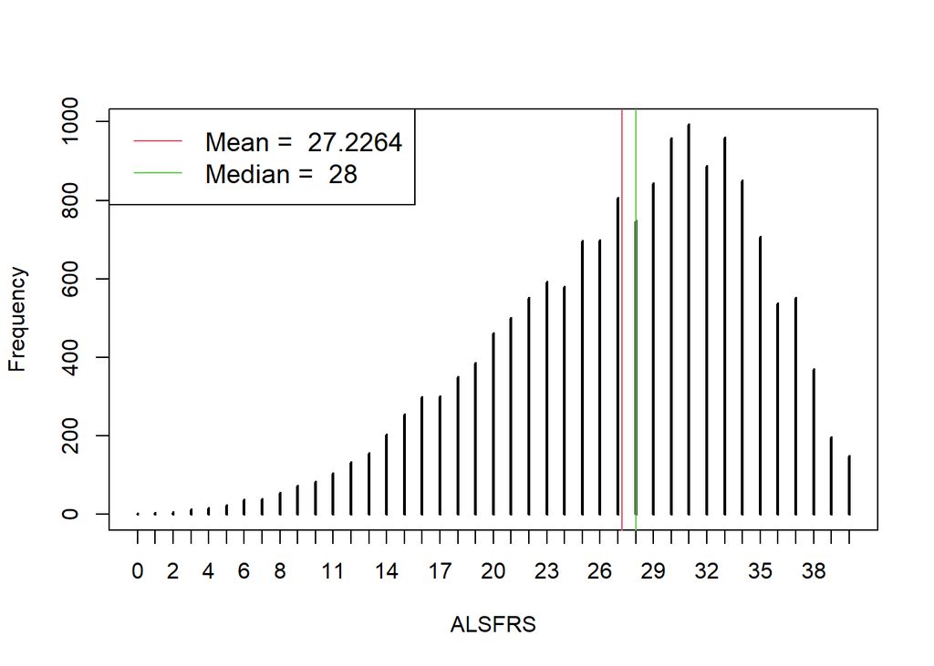

```r
#c(mean(sla$ALSFRS_Total),median(sla$ALSFRS_Total))
plot(table(sla$ALSFRS_Total), xlab = "ALSFRS", ylab = "Frequency")
abline(v = mean(sla$ALSFRS_Total), col = 2, lwd = 1)
abline(v = median(sla$ALSFRS_Total), col = 3, lwd = 1)
legend(x = "topleft", legend = c(paste("Mean = ", round(mean(sla$ALSFRS_Total), 4)),
                                       paste("Median = ", median(sla$ALSFRS_Total))),
       lty = c(1,1), col = c(2,3), lwd = c(1,1), cex = 1.2)
```

```r
#We get rid of the first column, which is the observation index
sla1=sla[,-1]

indices1 = sample(1:nrow(sla1),12000)
slaTrain1=sla1[indices1,]
slaTest1=sla1[-indices1,]

indices2 = sample(1:nrow(slaTrain1),8000)
slaTrain2=slaTrain1[indices2,]
slaTest2=slaTrain1[-indices2,]

#Now we prepare the model matrices for LASSO regression

#x.train = model.matrix(~.,data=slaTrain2[,-1]) #We get rid of dependent variable
#x.test = model.matrix(~.,data=slaTest1[,-1])
```

Now we train the linear models, first a full model and then we iteratively remove independent variables until arriving at a reduced model, based on AIC.

```r
lmTrain2=lm(slaTrain2$ALSFRS_Total~.,data=slaTrain2) #Fit full model
lmTrain2b = step(lmTrain2, direction = "backward", trace=1 ) #Get reduced model
```

```
## Start:  AIC=28859.61
## slaTrain2$ALSFRS_Total ~ subject_id + Age + Sex + Ethnicity +
##     Race + Blood_Pressure_Diastolic + Blood_Pressure_Systolic +
##     Pulse + Respiratory_Rate + Onset_Site + Delta + BMI + ABSOLUTE.BASOPHIL.COUNT +
##     ABSOLUTE.EOSINOPHIL.COUNT + ABSOLUTE.LYMPHOCYTE.COUNT + ABSOLUTE.MONOCYTE.COUNT +
##     ABSOLUTE.NEUTROPHIL.COUNT + ALBUMIN + ALKALINE.PHOSPHATASE +
##     ALT.SGPT. + AST.SGOT. + BASOPHILS + BICARBONATE + BILIRUBIN..TOTAL. +
##     BLOOD.UREA.NITROGEN..BUN. + CALCIUM + CHLORIDE + CK + CREATININE +
##     EOSINOPHILS + GAMMA.GLUTAMYLTRANSFERASE + GLUCOSE + HEMATOCRIT +
##     HEMOGLOBIN + LYMPHOCYTES + MONOCYTES + PHOSPHORUS + PLATELETS +
##     POTASSIUM + PROTEIN + RED.BLOOD.CELLS..RBC. + SODIUM + URINE.PH +
##     WHITE.BLOOD.CELL..WBC.
##
##                             Df Sum of Sq    RSS   AIC
## - EOSINOPHILS                1       0.5 291385 28858
## - Ethnicity                  1       2.9 291387 28858
## - ABSOLUTE.EOSINOPHIL.COUNT  1       7.6 291392 28858
## - BASOPHILS                  1       9.9 291394 28858
## - ABSOLUTE.LYMPHOCYTE.COUNT  1      10.0 291394 28858
## - ABSOLUTE.BASOPHIL.COUNT    1      14.6 291399 28858
## - PROTEIN                    1      17.2 291402 28858
## - subject_id                 1      18.6 291403 28858
## - HEMOGLOBIN                 1      34.8 291419 28859
## - PLATELETS                  1      38.3 291423 28859
## - Age                        1      40.2 291425 28859
## - BLOOD.UREA.NITROGEN..BUN.  1      44.7 291429 28859
## - LYMPHOCYTES                1      54.6 291439 28859
## - GLUCOSE                    1      60.7 291445 28859
## - WHITE.BLOOD.CELL..WBC.     1      71.6 291456 28860
## <none>                                   291384 28860
## - GAMMA.GLUTAMYLTRANSFERASE  1      77.9 291462 28860
## - ABSOLUTE.NEUTROPHIL.COUNT  1      94.7 291479 28860
## - HEMATOCRIT                 1     140.4 291525 28862
## - BMI                        1     170.6 291555 28862
## - ABSOLUTE.MONOCYTE.COUNT    1     197.4 291582 28863
## - MONOCYTES                  1     219.0 291603 28864
## - CHLORIDE                   1     247.4 291632 28864
## - BILIRUBIN..TOTAL.          1     258.0 291642 28865
## - RED.BLOOD.CELLS..RBC.      1     267.0 291651 28865
## - Blood_Pressure_Diastolic   1     299.4 291684 28866
```

[output cut: 711 more lines]

```
## - ALKALINE.PHOSPHATASE       1       990 292767 28868
## - AST.SGOT.                  1      1118 292895 28871
## - Race                       3      1343 293120 28873
## - ALBUMIN                    1      1687 293464 28887
## - CALCIUM                    1      2117 293894 28898
## - BICARBONATE                1      2506 294283 28909
## - Blood_Pressure_Systolic    1      2849 294626 28918
## - Onset_Site                 3      3025 294802 28919
## - Pulse                      1      3585 295362 28938
## - Sex                        1      5335 297112 28985
## - PHOSPHORUS                 1      5483 297260 28989
## - Delta                      1      5643 297420 28994
## - Respiratory_Rate           1      6935 298712 29028
## - CK                         1      7824 299601 29052
## - CREATININE                 1     31791 323568 29668
```

We will calculate the MSE of both linear models using the data in `slaTest2` and choose the one that fares better.

```r
predict.lmTrain2=predict(lmTrain2,newdata = slaTest2)
predict.lmTrain2b=predict(lmTrain2b,newdata = slaTest2)
mse.lmTrain2=mean((predict.lmTrain2-slaTest2$ALSFRS_Total)^2)
mse.lmTrain2b=mean((predict.lmTrain2b-slaTest2$ALSFRS_Total)^2)

MSEtable = list(MSE = c(mse.lmTrain2, mse.lmTrain2b), NAMES = c("MSE of full lm is",
                                                                 "MSE of reduced lm is"))
paste(MSEtable$NAMES, MSEtable$MSE)
```

```
## [1] "MSE of full lm is 37.2175428367416"
## [2] "MSE of reduced lm is 37.2590092759683"
```

This chunk prints out the winning model (in this case among full linear model and reduced linear model).

```r
#It is important that the model names match the variable names that you used for them

input = list(MODELS = c("lmTrain2", "lmTrain2b"), MSE = c(mse.lmTrain2, mse.lmTrain2b))
bestmodel = function (myinput)
{
  paste("The winning model is",
        myinput$MODELS[which.min(myinput$MSE)])
}
bestmodel(input)
```

```
## [1] "The winning model is lmTrain2"
```

We fit the regression tree on `slaTrain2` and prune it on `slaTest2`.

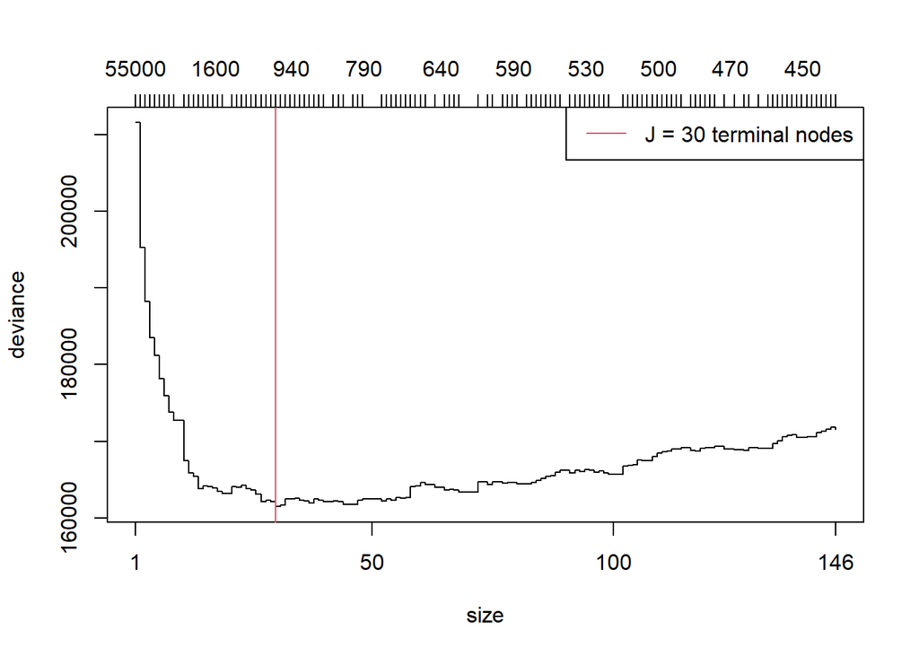

```r
library(tree)

tree1 = tree(ALSFRS_Total~.,data=slaTrain2,control=tree.control(nobs=nrow(slaTrain2),
                                                                minsize=2,mindev = 0.001))
prune.tree1 = prune.tree(tree1, newdata = slaTest2)

J = prune.tree1$size[prune.tree1$dev==min(prune.tree1$dev)]
treeBEST = prune.tree(tree1, best = J)
plot(prune.tree1) #x-axis shows number of terminal nodes, we chose one that minimizes the deviance, top part of x-axis shows a "tuning constant" used at each size to find the best tree
abline(v = J, col = 2)
legend(x = "topright", legend = paste("J =", J, "terminal nodes"), col = 2, lty = 1)
```

```r
#head(data.frame(slaTest1$ALSFRS_Total, predict.treeBEST), n = 15)
```

We test the best linear model and the best tree on `slaTest1` and choose the winner, we print the first 10 predictions as well.

```r
bestPredict = function(myinput) #returns "modelname", input should look like
#  list(MODELS = c("lmTrain2", "lmTrain2b"), MSE = c(mse.lmTrain2, mse.lmTrain2b))
{
  myinput$MODELS[which.min(myinput$MSE)]
}

predict.lmBEST = predict(get(bestPredict(input)), newdata = slaTest1)
mse.lmBEST = mean((predict.lmBEST-slaTest1$ALSFRS_Total)^2)

predict.treeBEST = predict(treeBEST, newdata = slaTest1)
mse.treeBEST = mean((predict.treeBEST-slaTest1$ALSFRS_Total)^2)

MSEtableFinal = list(MSE = c(mse.treeBEST, mse.lmBEST), NAMES = c("MSE of best tree is",
                                                                 "MSE of best lm is"))
paste(MSEtableFinal$NAMES, MSEtableFinal$MSE)
```

```
## [1] "MSE of best tree is 38.6466247026164"
## [2] "MSE of best lm is 35.7157322950796"
```

```r
input2 = list(MODELS = c(bestPredict(input), "treeBEST"),
              MSE = c(mse.lmBEST), mse.treeBEST)


if (bestPredict(input2) == "treeBEST")
{
  head(data.frame(slaTest1$ALSFRS_Total, predict.treeBEST), n = 10)
} else
{
  head(data.frame(slaTest1$ALSFRS_Total, predict.lmBEST), n = 10)
}
```

```
##    slaTest1.ALSFRS_Total predict.lmBEST
## 1                     31       27.71830
## 3                     30       27.52001
## 5                     31       26.40825
## 6                     27       22.59621
## 12                    30       27.66466
## 14                    24       23.24889
## 17                    19       23.12176
## 19                    22       26.33912
## 20                    22       23.39286
## 21                    19       19.97001
```